# Course Project Description

Julie Lee

```r
library(dplyr)
library(tidyverse)
```

```r
library(ggplot2)
```

**SECTION 1 INTRODUCTION:**

Each of the 18 sessions recorded is composed of several hundred trials. Each trail is composed of a couple hundred trials that that include information regarding the 6 variables: 1. Feedback type (type of feedback, 1 for success and -1 for failure.) 2. contrast_left: contrast of the left stimulus. 3. contrast_right: contrast of the right stimulus. 4. time: centers of the time bins for spks. 5. spk: number of spikes of neurons in the visual cortex in time bins defined in time 6. brain_area: area of the brain where each neuron lives

When left contrast > right contrast, success (1) if turning the wheel to the right and failure (-1) otherwise. When right contrast > left contrast, success (1) if turning the wheel to the left and failure (-1) otherwise. When both left and right contrasts are zero, success (1) if holding the wheel still and failure (-1) otherwise. When left and right contrasts are equal but non-zero, left or right will be randomly chosen (50%) as the correct choice.

The following code lists the corresponding experiment dates and mouse name of each session (Session 1 to 18).

```r
session=list()
for(i in 1:18){
  session[[i]]=readRDS(paste('datasets/session',i,'.rds',sep=''))
  print(session[[i]]$mouse_name)
  print(session[[i]]$date_exp)
}
```

```
## [1] "Cori"
## [1] "2016-12-14"
## [1] "Cori"
## [1] "2016-12-17"
## [1] "Cori"
## [1] "2016-12-18"
## [1] "Forssmann"
## [1] "2017-11-01"
## [1] "Forssmann"
## [1] "2017-11-02"
## [1] "Forssmann"
## [1] "2017-11-04"
## [1] "Forssmann"
## [1] "2017-11-05"
## [1] "Hench"
```

[output cut: 21 more lines]

**SECTION 2 EXPLORATORY ANALYSIS:**

Features of the data sets to build prediction model.

1. Data structures across sessions (number of neurons, number of trials, stimuli conditions, feedback types):

```r
library(knitr)
# Create an empty data frame
summary_table <- data.frame(
  Session_Number = numeric(),
  Experiment_Date = character(),
  Mouse_Name = character(),
  Number_Neurons = numeric(),
  Number_Trials = numeric(),
  Unique_Stimuli_Conditions = character(),
  Unique_Feedback_Types = character(),
  stringsAsFactors = FALSE
)

# Loop through each session
for (i in 1:18) {
  session_data <- session[[i]]  # Access the data for the current session
  session_number <- i
  experiment_date <- unique(session_data$date_exp)
  mouse_name <- unique(session_data$mouse_name)
  number_neurons <- length(session_data$brain_area)
  number_trials <- length(session_data$feedback)
  unique_stimuli_conditions <- paste("Contrast_Left:", paste(unique(session_data$contrast_left), collapse = ", "),
                                      "Contrast_Right:", paste(unique(session_data$contrast_right), collapse = ", "))
  unique_feedback_types <- paste(unique(session_data$feedback_type), collapse = ", ")

  # Append data to the summary table
  summary_table <- rbind(summary_table, data.frame(
    Session_Number = session_number,
    Experiment_Date = experiment_date,
    Mouse_Name = mouse_name,
    Number_Neurons = number_neurons,
    Number_Trials = number_trials,
    Unique_Stimuli_Conditions = unique_stimuli_conditions,
    Unique_Feedback_Types = unique_feedback_types
  ))
}

# Print summary table with kable
print(kable(summary_table))
```

```
##
##
## | Session_Number|Experiment_Date |Mouse_Name | Number_Neurons| Number_Trials|Unique_Stimuli_Conditions                                      |Unique_Feedback_Types |
## |--------------:|:---------------|:----------|--------------:|-------------:|:--------------------------------------------------------------|:---------------------|
## |              1|2016-12-14      |Cori       |            734|           114|Contrast_Left: 0, 0.5, 1, 0.25 Contrast_Right: 0.5, 0, 1, 0.25 |1, -1                 |
## |              2|2016-12-17      |Cori       |           1070|           251|Contrast_Left: 1, 0.25, 0.5, 0 Contrast_Right: 1, 0, 0.5, 0.25 |-1, 1                 |
## |              3|2016-12-18      |Cori       |            619|           228|Contrast_Left: 0.5, 1, 0, 0.25 Contrast_Right: 0, 1, 0.5, 0.25 |1, -1                 |
## |              4|2017-11-01      |Forssmann  |           1769|           249|Contrast_Left: 0, 0.5, 0.25, 1 Contrast_Right: 1, 0.5, 0.25, 0 |1, -1                 |
## |              5|2017-11-02      |Forssmann  |           1077|           254|Contrast_Left: 0, 0.25, 0.5, 1 Contrast_Right: 1, 0, 0.25, 0.5 |1, -1                 |
## |              6|2017-11-04      |Forssmann  |           1169|           290|Contrast_Left: 0.25, 0, 1, 0.5 Contrast_Right: 0, 0.5, 1, 0.25 |1, -1                 |
## |              7|2017-11-05      |Forssmann  |            584|           252|Contrast_Left: 1, 0, 0.25, 0.5 Contrast_Right: 0.5, 0, 1, 0.25 |1, -1                 |
## |              8|2017-06-15      |Hench      |           1157|           250|Contrast_Left: 0, 1, 0.5, 0.25 Contrast_Right: 0.5, 0, 1, 0.25 |1, -1                 |
## |              9|2017-06-16      |Hench      |            788|           372|Contrast_Left: 1, 0.5, 0, 0.25 Contrast_Right: 0.25, 0, 0.5, 1 |1, -1                 |
## |             10|2017-06-17      |Hench      |           1172|           447|Contrast_Left: 0, 0.5, 1, 0.25 Contrast_Right: 1, 0.5, 0, 0.25 |-1, 1                 |
## |             11|2017-06-18      |Hench      |            857|           342|Contrast_Left: 0.5, 0, 1, 0.25 Contrast_Right: 0.5, 1, 0, 0.25 |1, -1                 |
## |             12|2017-12-05      |Lederberg  |            698|           340|Contrast_Left: 0, 1, 0.25, 0.5 Contrast_Right: 0, 0.5, 1, 0.25 |1, -1                 |
## |             13|2017-12-06      |Lederberg  |            983|           300|Contrast_Left: 0, 0.5, 0.25, 1 Contrast_Right: 0, 1, 0.25, 0.5 |-1, 1                 |
## |             14|2017-12-07      |Lederberg  |            756|           268|Contrast_Left: 1, 0, 0.25, 0.5 Contrast_Right: 0, 0.25, 1, 0.5 |1, -1                 |
## |             15|2017-12-08      |Lederberg  |            743|           404|Contrast_Left: 0.5, 0, 0.25, 1 Contrast_Right: 0, 1, 0.25, 0.5 |1, -1                 |
## |             16|2017-12-09      |Lederberg  |            474|           280|Contrast_Left: 1, 0, 0.5, 0.25 Contrast_Right: 0.25, 0, 1, 0.5 |1, -1                 |
## |             17|2017-12-10      |Lederberg  |            565|           224|Contrast_Left: 0, 0.5, 0.25, 1 Contrast_Right: 0, 1, 0.5, 0.25 |-1, 1                 |
## |             18|2017-12-11      |Lederberg  |           1090|           216|Contrast_Left: 0.5, 1, 0, 0.25 Contrast_Right: 0, 0.25, 0.5, 1 |1, -1                 |
```

```r
library(knitr)

 within_session_combined_data <- data.frame(
  Session_number = numeric(),
  Trial_Number = numeric(),
  Mouse_Name = character(),
  Date_Exp = character(),
  Contrast_Left = numeric(),
  Contrast_Right = numeric(),
  Feedback_Type = numeric(),
  Number_Neurons = numeric(),
  Number_Time_Bins = numeric(),
  Unique_Brain_Areas = numeric(),
  stringsAsFactors = FALSE
)

for (i in 1:18) {
  session_data <- session[[i]]
  feedback_label <- ifelse(session_data$feedback_type == 1, "Success", "Failure")

  within_session_combined_data <- rbind(
    within_session_combined_data,
    data.frame(
      Session_Number = i,
      Trial_Number = seq_along(session_data$contrast_left),
      Mouse_Name = session_data$mouse_name,
      Date_Exp = session_data$date_exp,
      Contrast_Left = session_data$contrast_left,
      Contrast_Right = session_data$contrast_right,
      Feedback_Type =  feedback_label,
      Number_Neurons = length(session_data$brain_area),
      Number_Time_Bins = ncol(session_data$spks[[1]]),
      Unique_Brain_Areas = length(unique(session_data$brain_area))
    )
  )
}
rownames(within_session_combined_data) <- NULL

kable(head(within_session_combined_data, 10), caption = "Combined Data for Each Session")
```

Combined Data for Each Session

| Session_Number | Trial_Number | Mouse_Name | Date_Exp | Contrast_Left | Contrast_Right | Feedback_Type | Number_Neurons | Number_Time_Bins | Unique_Brain_Areas |
| --- | --- | --- | --- | --- | --- | --- | --- | --- | --- |
| 1 | 1 | Cori | 2016-12-14 | 0.0 | 0.50 | Success | 734 | 40 | 8 |
| 1 | 2 | Cori | 2016-12-14 | 0.0 | 0.00 | Success | 734 | 40 | 8 |
| 1 | 3 | Cori | 2016-12-14 | 0.5 | 1.00 | Failure | 734 | 40 | 8 |
| 1 | 4 | Cori | 2016-12-14 | 0.0 | 0.00 | Failure | 734 | 40 | 8 |
| 1 | 5 | Cori | 2016-12-14 | 0.0 | 0.00 | Failure | 734 | 40 | 8 |
| 1 | 6 | Cori | 2016-12-14 | 0.0 | 0.00 | Success | 734 | 40 | 8 |
| 1 | 7 | Cori | 2016-12-14 | 1.0 | 0.50 | Success | 734 | 40 | 8 |
| 1 | 8 | Cori | 2016-12-14 | 0.5 | 0.00 | Success | 734 | 40 | 8 |
| 1 | 9 | Cori | 2016-12-14 | 0.0 | 0.00 | Success | 734 | 40 | 8 |
| 1 | 10 | Cori | 2016-12-14 | 0.5 | 0.25 | Success | 734 | 40 | 8 |

```r
kable(tail(within_session_combined_data, 10), caption = "Combined Data for Each Session")
```

Combined Data for Each Session

|  | Session_Number | Trial_Number | Mouse_Name | Date_Exp | Contrast_Left | Contrast_Right | Feedback_Type | Number_Neurons | Number_Time_Bins | Unique_Brain_Areas |
| --- | --- | --- | --- | --- | --- | --- | --- | --- | --- | --- |
| 5072 | 18 | 207 | Lederberg | 2017-12-11 | 0.50 | 1.0 | Success | 1090 | 40 | 10 |
| 5073 | 18 | 208 | Lederberg | 2017-12-11 | 1.00 | 0.5 | Failure | 1090 | 40 | 10 |
| 5074 | 18 | 209 | Lederberg | 2017-12-11 | 0.00 | 0.0 | Success | 1090 | 40 | 10 |
| 5075 | 18 | 210 | Lederberg | 2017-12-11 | 0.25 | 0.5 | Failure | 1090 | 40 | 10 |
| 5076 | 18 | 211 | Lederberg | 2017-12-11 | 1.00 | 0.0 | Failure | 1090 | 40 | 10 |
| 5077 | 18 | 212 | Lederberg | 2017-12-11 | 1.00 | 0.0 | Failure | 1090 | 40 | 10 |
| 5078 | 18 | 213 | Lederberg | 2017-12-11 | 1.00 | 0.0 | Success | 1090 | 40 | 10 |
| 5079 | 18 | 214 | Lederberg | 2017-12-11 | 0.00 | 0.5 | Success | 1090 | 40 | 10 |
| 5080 | 18 | 215 | Lederberg | 2017-12-11 | 0.50 | 1.0 | Failure | 1090 | 40 | 10 |
| 5081 | 18 | 216 | Lederberg | 2017-12-11 | 0.00 | 1.0 | Failure | 1090 | 40 | 10 |

2. Neural Activities during each trial

For each session, list out the unique brain areas for each session for better visualization: Total Number of unique Brain Areas across all 18 sessions: 62 unique brain areas

```r
unique_brain_areas_table <- data.frame(Session_Number = 1:18, Unique_Brain_Areas = NA, Total_Unique_Brain_Areas = NA)
for (i in 1:18) {
    unique_areas <- unique(session[[i]]$brain_area)
    unique_areas_string <- paste(unique_areas, collapse = ", ")
    unique_brain_areas_table[i, "Unique_Brain_Areas"] <- unique_areas_string
    total_unique_areas <- length(unique_areas)
    unique_brain_areas_table[i, "Total_Unique_Brain_Areas"] <- total_unique_areas
}
kable(unique_brain_areas_table, caption = "Unique Brain Areas in Each Session")
```

Unique Brain Areas in Each Session

| Session_Number | Unique_Brain_Areas | Total_Unique_Brain_Areas |
| --- | --- | --- |
| 1 | ACA, MOs, LS, root, VISp, CA3, SUB, DG | 8 |
| 2 | CA1, VISl, root, VISpm, POST | 5 |
| 3 | DG, VISam, MG, CA1, SPF, root, LP, MRN, POST, NB, VISp | 11 |
| 4 | LGd, DG, TH, SUB, VPL, VISp, CA1, VISa, LSr, ACA, MOs | 11 |
| 5 | VISa, root, CA1, SUB, DG, OLF, ORB, ACA, PL, MOs | 10 |
| 6 | AUD, root, SSp, CA1, TH | 5 |
| 7 | VPL, root, CA3, LD, CP, EPd, SSp, PIR | 8 |
| 8 | ILA, TT, MOs, PL, LSr, root, LD, PO, CA3, VISa, CA1, LP, DG, VISp, SUB | 15 |
| 9 | TT, ORBm, PL, LSr, root, CA3, VISl, CA1, TH, VISam, VPL, LD | 12 |
| 10 | MB, VISp, SCm, SCsg, POST, DG, MRN, CA1, VISl, POL, root, GPe, VISrl | 13 |
| 11 | MOp, LSc, root, PT, CP, LSr | 6 |
| 12 | VISp, DG, SUB, LGd, PL, root, MOs, ACA, CA1, VISam, MD, LH | 12 |
| 13 | VISam, ZI, DG, CA1, LGd, MB, SCs, RN, MRN, SCm, ACA, PL, MS, root, MOs | 15 |
| 14 | ORB, MOs, root, MRN, SCm, SCs, VISp, RSP, CA1, PAG | 10 |
| 15 | BLA, GPe, root, VPM, LGd, ZI, MB, CA3 | 8 |
| 16 | SSs, SSp, MB, TH, LGd, CA3 | 6 |
| 17 | root, VPL, VPM, RT, MEA, LD | 6 |
| 18 | CP, ACB, OT, SI, SNr, LGd, ZI, CA3, root, TH | 10 |

Comprehensive report of Number of Spikes in Every Time Bin organized by Neuron Type across all trials of each session (1-18). Below, I only called the function to provide me an output for the corresponding information from Session #1:

```r
load_session_data <- function(session_number) {
  neural_activity_session <- data.frame()

  for (i in 1:length(session[[session_number]]$spks)) {
    spks_matrix <- session[[session_number]]$spks[[i]]
    spks_df <- as.data.frame(spks_matrix)

    rownames(spks_df) <- paste("Trial_", i, "_Neuron_", 1:nrow(spks_matrix))
    colnames(spks_df) <- paste("#Spikes of Neurons in Time Bin ", 1:ncol(spks_matrix), sep = "")

    trial_number <- rep(i, nrow(spks_df))
    spks_df$Trial <- trial_number

    neuron_number <- 1:nrow(spks_matrix)
    spks_df$Neuron_Number <- neuron_number

    brain_area <- session[[session_number]]$brain_area
    spks_df$brain_area <- brain_area

    if (nrow(neural_activity_session) == 0) {
      neural_activity_session <- spks_df
    } else {
      neural_activity_session <- rbind(neural_activity_session, spks_df)
    }
  }

  neural_activity_session <- neural_activity_session[, c("Trial", "Neuron_Number", "brain_area", setdiff(names(neural_activity_session), c("Trial", "Neuron_Number", "brain_area")))]

  return(neural_activity_session)
}

neural_activity_session_1 <- load_session_data(1)
head(neural_activity_session_1)
```

```
##                     Trial Neuron_Number brain_area
## Trial_ 1 _Neuron_ 1     1             1        ACA
## Trial_ 1 _Neuron_ 2     1             2        MOs
## Trial_ 1 _Neuron_ 3     1             3        ACA
## Trial_ 1 _Neuron_ 4     1             4         LS
## Trial_ 1 _Neuron_ 5     1             5        MOs
## Trial_ 1 _Neuron_ 6     1             6        ACA
##                     #Spikes of Neurons in Time Bin 1
## Trial_ 1 _Neuron_ 1                                0
## Trial_ 1 _Neuron_ 2                                0
## Trial_ 1 _Neuron_ 3                                0
## Trial_ 1 _Neuron_ 4                                0
## Trial_ 1 _Neuron_ 5                                0
## Trial_ 1 _Neuron_ 6                                0
##                     #Spikes of Neurons in Time Bin 2
## Trial_ 1 _Neuron_ 1                                0
## Trial_ 1 _Neuron_ 2                                0
## Trial_ 1 _Neuron_ 3                                0
## Trial_ 1 _Neuron_ 4                                0
## Trial_ 1 _Neuron_ 5                                0
## Trial_ 1 _Neuron_ 6                                0
##                     #Spikes of Neurons in Time Bin 3
## Trial_ 1 _Neuron_ 1                                0
## Trial_ 1 _Neuron_ 2                                0
## Trial_ 1 _Neuron_ 3                                0
## Trial_ 1 _Neuron_ 4                                0
## Trial_ 1 _Neuron_ 5                                0
## Trial_ 1 _Neuron_ 6                                1
##                     #Spikes of Neurons in Time Bin 4
## Trial_ 1 _Neuron_ 1                                0
## Trial_ 1 _Neuron_ 2                                0
## Trial_ 1 _Neuron_ 3                                0
## Trial_ 1 _Neuron_ 4                                0
## Trial_ 1 _Neuron_ 5                                0
## Trial_ 1 _Neuron_ 6                                0
##                     #Spikes of Neurons in Time Bin 5
## Trial_ 1 _Neuron_ 1                                0
## Trial_ 1 _Neuron_ 2                                0
## Trial_ 1 _Neuron_ 3                                0
## Trial_ 1 _Neuron_ 4                                0
```

[output cut: 232 more lines]

```
## Trial_ 1 _Neuron_ 6                                 0
##                     #Spikes of Neurons in Time Bin 39
## Trial_ 1 _Neuron_ 1                                 0
## Trial_ 1 _Neuron_ 2                                 0
## Trial_ 1 _Neuron_ 3                                 0
## Trial_ 1 _Neuron_ 4                                 0
## Trial_ 1 _Neuron_ 5                                 0
## Trial_ 1 _Neuron_ 6                                 0
##                     #Spikes of Neurons in Time Bin 40
## Trial_ 1 _Neuron_ 1                                 0
## Trial_ 1 _Neuron_ 2                                 0
## Trial_ 1 _Neuron_ 3                                 0
## Trial_ 1 _Neuron_ 4                                 0
## Trial_ 1 _Neuron_ 5                                 0
## Trial_ 1 _Neuron_ 6                                 0
```

Spike Information for a particular chosen trial of Session #1. In this particular example, we investigate the total number of spike counts (across all 40 time bins) of Trial #1 of Session #1 grouped by Brain Area.

```r
calculate_average_spikes <- function(session_number, trial_number) {
  # Load data for the specified session
  neural_activity_session <- load_session_data(session_number)

  trial_spike <- neural_activity_session %>%
    filter(Trial == trial_number) %>%
    group_by(brain_area) %>%
    summarise(Total_Spikes = sum(across(starts_with("#Spikes of Neurons in Time Bin"))))

  trial_brain_area <- neural_activity_session %>%
    filter(Trial == trial_number) %>%
    group_by(brain_area) %>%
    count(name = "Total_Brain_Areas")
  trial_average <- inner_join(trial_spike, trial_brain_area, by = "brain_area") %>%
    mutate(Average_Spikes = Total_Spikes / Total_Brain_Areas)

  return(trial_average)
}

session_trial_spike <- calculate_average_spikes(session_number = 1, trial_number = 1) #Session number = 1 and trial number = 1.
print(kable(session_trial_spike))
```

```
##
##
## |brain_area | Total_Spikes| Total_Brain_Areas| Average_Spikes|
## |:----------|------------:|-----------------:|--------------:|
## |ACA        |          138|               109|      1.2660550|
## |CA3        |          104|                68|      1.5294118|
## |DG         |           79|                34|      2.3235294|
## |LS         |          269|               139|      1.9352518|
## |MOs        |          106|               113|      0.9380531|
## |SUB        |          156|                75|      2.0800000|
## |VISp       |          300|               178|      1.6853933|
## |root       |            9|                18|      0.5000000|
```

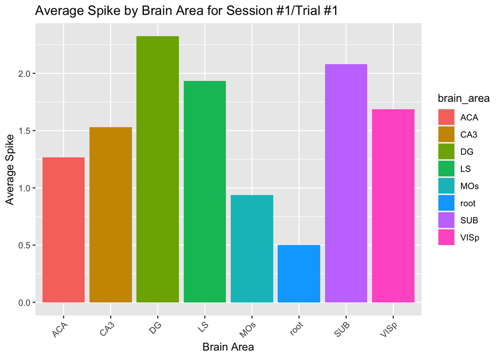

```r
ggplot(session_trial_spike, aes(x = brain_area, y = Average_Spikes, fill = brain_area)) +
  geom_bar(stat = "identity") +
  labs(x = "Brain Area", y = "Average Spike", title = "Average Spike by Brain Area for Session #1/Trial #1") +
  theme(axis.text.x = element_text(angle = 45, hjust = 1))  # Rotate x-axis labels for better readability
```

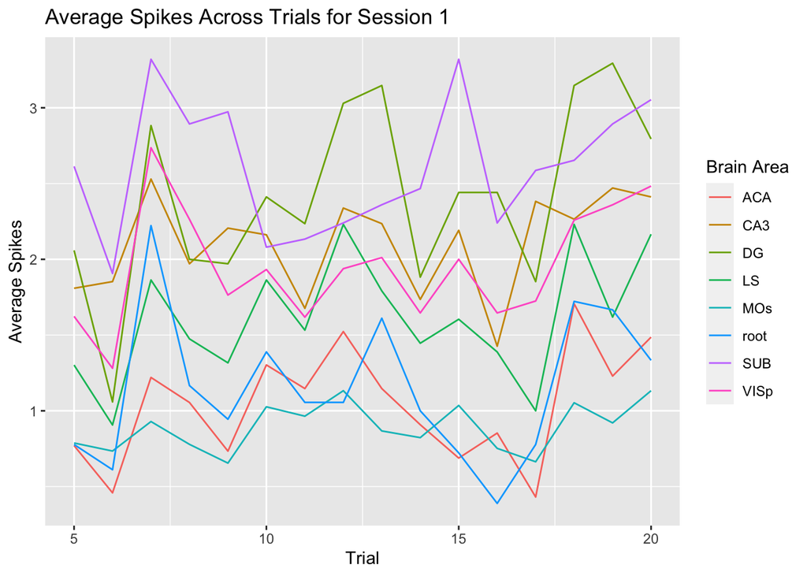

```r
plot_average_spikes_zoom <- function(session_number, start_trial, end_trial) {
  # Load data for the specified session
  neural_activity_session <- load_session_data(session_number)

  combined_data <- data.frame()
  for (trial_number in start_trial:end_trial) {
    trial_spike <- neural_activity_session %>%
      filter(Trial == trial_number) %>%
      group_by(brain_area) %>%
      summarise(Total_Spikes = sum(across(starts_with("#Spikes of Neurons in Time Bin"))))
    trial_brain_area <- neural_activity_session %>%
      filter(Trial == trial_number) %>%
      group_by(brain_area) %>%
      count(name = "Total_Brain_Areas")

    trial_average <- inner_join(trial_spike, trial_brain_area, by = "brain_area") %>%
      mutate(Average_Spikes = Total_Spikes / Total_Brain_Areas) %>%
      mutate(Trial = trial_number)  # Add trial number to the data

    combined_data <- rbind(combined_data, trial_average)
  }

  ggplot(combined_data, aes(x = Trial, y = Average_Spikes, color = brain_area)) +
    geom_line() +
    labs(x = "Trial", y = "Average Spikes", title = paste("Average Spikes Across Trials for Session", session_number)) +
    scale_color_discrete(name = "Brain Area") +
    xlim(start_trial, end_trial)  # Set the x-axis limits
}
session_number <- 1
start_trial <- 5
end_trial <- 20
plot_average_spikes_zoom(session_number, start_trial, end_trial)
```

Spike Information Across all Trials from all 18 sessions: grouped by mouse_name:

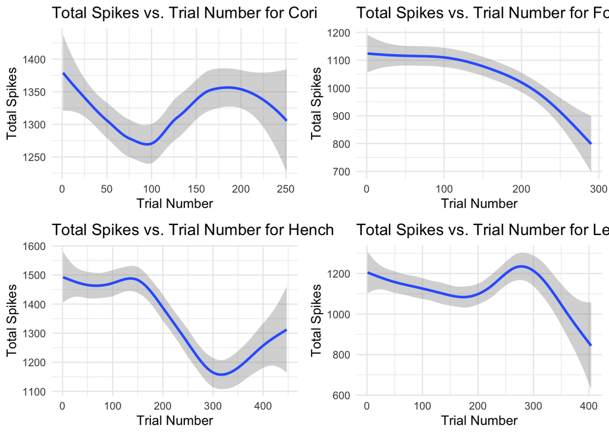

```r
library(ggplot2)
library(gridExtra)
library(grid)
library(lattice)

process_sessions_and_plot <- function(session_range, mouse_name) {
  trial_numbers_all <- numeric()
  total_spikes_per_trial_all <- numeric()

  for (session_index in session_range) {
    trial_numbers <- numeric()
    total_spikes_per_trial <- numeric()

    for (i in 1:length(session[[session_index]]$spks)) {
      total_spikes <- sum(session[[session_index]]$spks[[i]])
      trial_numbers <- c(trial_numbers, i)
      total_spikes_per_trial <- c(total_spikes_per_trial, total_spikes)
    }

    trial_numbers_all <- c(trial_numbers_all, trial_numbers)
    total_spikes_per_trial_all <- c(total_spikes_per_trial_all, total_spikes_per_trial)
  }

  trial_data_all <- data.frame(Trial = trial_numbers_all, Total_Spikes = total_spikes_per_trial_all)

  ggplot(trial_data_all, aes(x = Trial, y = Total_Spikes)) +
    geom_smooth() +
    labs(x = "Trial Number", y = "Total Spikes", title = paste("Total Spikes vs. Trial Number for", mouse_name)) +
    theme_minimal()
}
plot_cori <- process_sessions_and_plot(1:3, "Cori")
plot_forssman <- process_sessions_and_plot(4:7, "Forssman")
plot_hench <- process_sessions_and_plot(8:11, "Hench")
plot_lederberg <- process_sessions_and_plot(12:18, "Lederberg")
grid.arrange(plot_cori, plot_forssman, plot_hench, plot_lederberg, ncol = 2)
```

Spike Information Grouped by Mouse Name: Total Spikes, Number of Trials, and Average Spikes:

```r
total_spikes_table <- data.frame(Mouse_Name = character(), Total_Spikes = numeric(), Num_Trials = numeric(), Average_Spikes = numeric())

for (session_number in 1:18) {
  mouse_name <- session[[session_number]]$mouse_name
  total_spikes <- 0
  for (i in 1:length(session[[session_number]]$spks)) {
    total_spikes <- total_spikes + sum(session[[session_number]]$spks[[i]])
  }
  num_trials <- length(session[[session_number]]$spks)
  session_data <- data.frame(Mouse_Name = mouse_name, Total_Spikes = total_spikes, Num_Trials = num_trials)
  total_spikes_table <- rbind(total_spikes_table, session_data)
}

total_spikes_summary <- total_spikes_table %>%
  group_by(Mouse_Name) %>%
  summarise(Total_Spikes = sum(Total_Spikes),
            Num_Trials = sum(Num_Trials),
            Average_Spikes = Total_Spikes / Num_Trials)

total_spikes_summary
```

```
## # A tibble: 4 × 4
##   Mouse_Name Total_Spikes Num_Trials Average_Spikes
##   <chr>             <dbl>      <int>          <dbl>
## 1 Cori             784022        593          1322.
## 2 Forssmann       1109059       1045          1061.
## 3 Hench           1932830       1411          1370.
## 4 Lederberg       2308017       2032          1136.
```

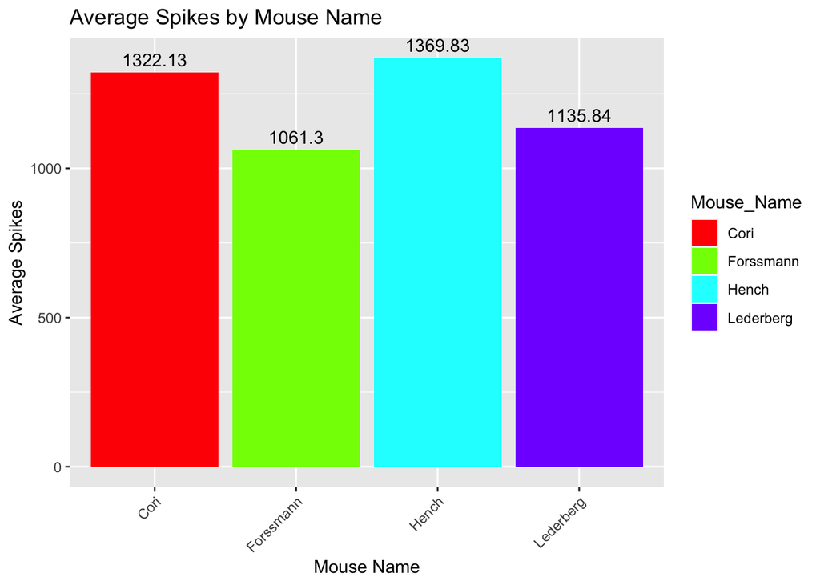

```r
ggplot(total_spikes_summary, aes(x = Mouse_Name, y = Average_Spikes, fill = Mouse_Name)) +
  geom_bar(stat = "identity") +
  geom_text(aes(label = round(Average_Spikes, 2)), vjust = -0.5) +  # Add labels for average spikes
  labs(x = "Mouse Name", y = "Average Spikes", title = "Average Spikes by Mouse Name") +
  scale_fill_manual(values = rainbow(nrow(total_spikes_summary))) +  # Set different colors for each mouse name
  theme(axis.text.x = element_text(angle = 45, hjust = 1))  # Rotate x-axis labels for better readability
```

3. Exploring the Spk changes across trials

Total Number of Spikes across Trials for Session #1:

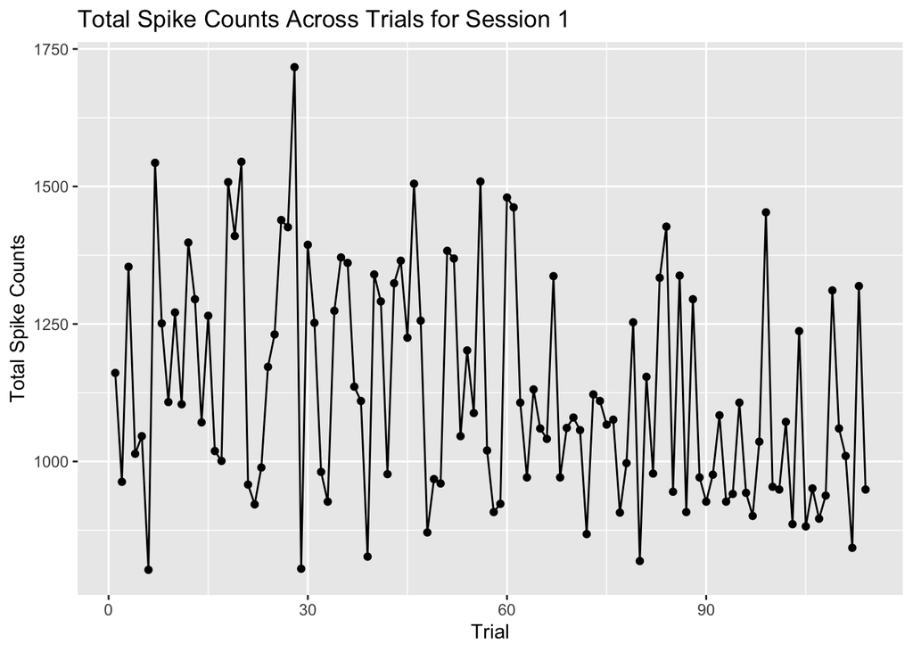

```r
plot_average_spikes_zoom <- function(session_number) {
  # Load data for the specified session
  neural_activity_session <- load_session_data(session_number)

  trial_numbers <- c()
  total_spikes <- c()

  for (trial_number in unique(neural_activity_session$Trial)) {
    trial_spike <- neural_activity_session %>%
      filter(Trial == trial_number) %>%
      summarise(Total_Spikes = sum(across(starts_with("#Spikes of Neurons in Time Bin"))))

    trial_numbers <- c(trial_numbers, trial_number)
    total_spikes <- c(total_spikes, trial_spike$Total_Spikes)
  }

  trial_data <- data.frame(Trial = trial_numbers, Total_Spikes = total_spikes)
  ggplot(trial_data, aes(x = Trial, y = Total_Spikes)) +
    geom_line() +
    geom_point() +
    labs(x = "Trial", y = "Total Spike Counts", title = paste("Total Spike Counts Across Trials for Session", session_number))
}

session_number <- 1
plot_average_spikes_zoom(session_number)
```

4. Exploring homogeneity and heterogeneity across sessions and mice

ACROSS ALL 18 SESSIONS:

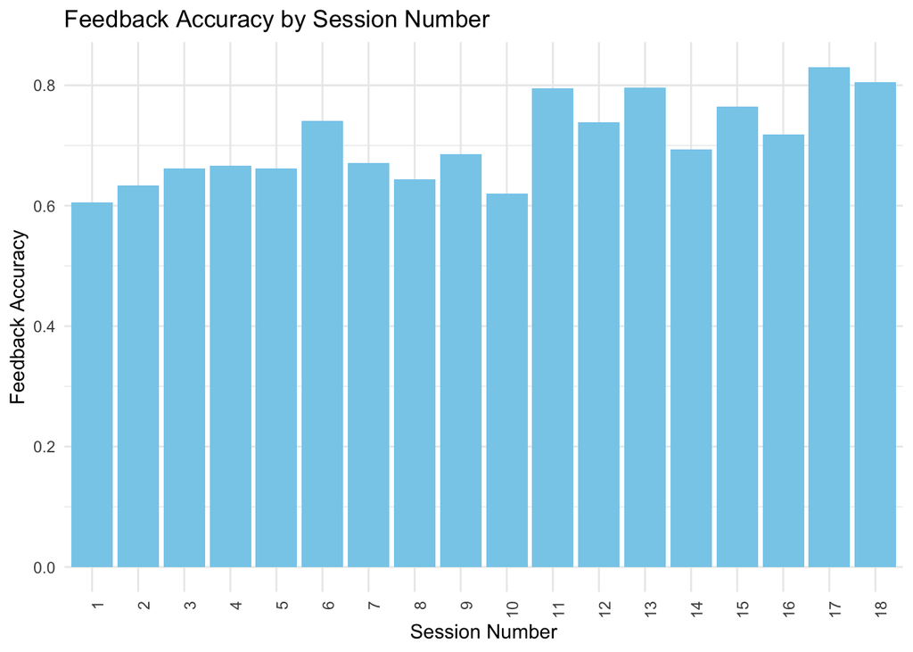

```r
# Initialize a vector to store accuracy values for each session
accuracy <- numeric(length = 18)

# Calculate accuracy for each session
for (i in 1:18) {
  session_data <- session[[i]]
  feedback_type <- session_data$feedback_type

  # Calculate accuracy as the proportion of correct feedback (feedback_type == 1)
  accuracy[i] <- mean(feedback_type == 1)
}

summary_table <- cbind(summary_table, Feedback_Accuracy = accuracy)

ggplot(mapping = aes(x = factor(1:18), y = accuracy)) +
  geom_bar(stat = "identity", fill = "skyblue") +
  labs(x = "Session Number", y = "Feedback Accuracy") +
  ggtitle("Feedback Accuracy by Session Number") +
  theme_minimal() +
  theme(axis.text.x = element_text(angle = 90, hjust = 1))  # Rotate x-axis labels for better readability
```

Feedback Type Accuracy Across Mice:

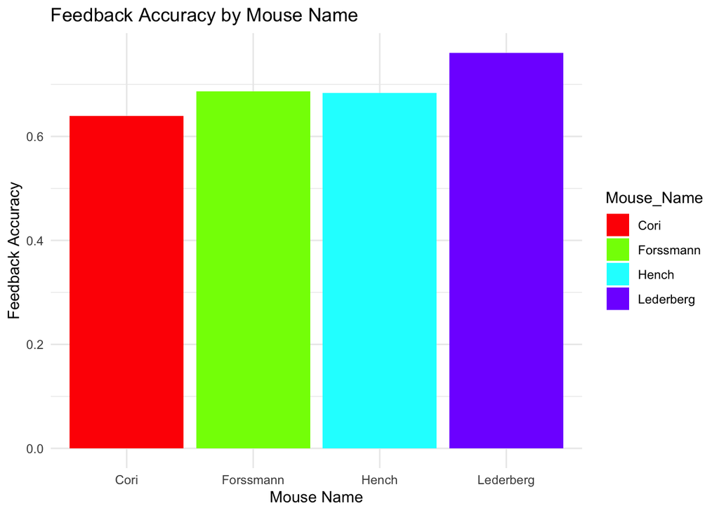

```r
accuracy_table <- within_session_combined_data %>%
  group_by(Mouse_Name) %>%
  summarise(
    successes = sum(Feedback_Type == "Success"),
    failures = sum(Feedback_Type == "Failure"),
    Feedback_Accuracy = successes / (successes + failures)
  )

accuracy_table <- accuracy_table %>%
  arrange(desc(Feedback_Accuracy))

unique_colors <- rainbow(length(unique(accuracy_table$Mouse_Name)))
ggplot(accuracy_table, aes(x = Mouse_Name, y = Feedback_Accuracy, fill = Mouse_Name)) +
  geom_bar(stat = "identity") +
  scale_fill_manual(values = unique_colors) +
  labs(x = "Mouse Name", y = "Feedback Accuracy") +
  ggtitle("Feedback Accuracy by Mouse Name") +
  theme(axis.text.x = element_text(angle = 90, hjust = 1)) +
  theme_minimal()
```

2. Addressing the differences between sessions

Differences in Mean Spikes in Each Trial of Each Session: Total number of Spikes in a Trial/Number of brain areas or neurons in a trial: Average_Spikes summarizes infromation regarding total number of spikes and number of brain areas/neurons.

This code is to add the Average Spike Counts column to the combined data set that lists out all 5081 trials of all 18 sessions:

```r
average_spikes_per_trial <- list()
for (i in 1:18) {
  session_average_spikes <- numeric()
  for (j in 1:length(session[[i]]$spks)) {
    trial_average_spikes <- sum(session[[i]]$spks[[j]]) / length(session[[i]]$brain_area)
    session_average_spikes <- c(session_average_spikes, trial_average_spikes)
  }

  average_spikes_per_trial[[i]] <- session_average_spikes
}
within_session_combined_data$Average_Spikes <- unlist(average_spikes_per_trial)
within_session_combined_data$Feedback_Type <- ifelse(within_session_combined_data$Feedback_Type =="Success", 1, 0)
within_session_combined_data$Feedback_Type <- as.factor(within_session_combined_data$Feedback_Type)
head(within_session_combined_data)
```

```
##   Session_Number Trial_Number Mouse_Name   Date_Exp Contrast_Left
## 1              1            1       Cori 2016-12-14           0.0
## 2              1            2       Cori 2016-12-14           0.0
## 3              1            3       Cori 2016-12-14           0.5
## 4              1            4       Cori 2016-12-14           0.0
## 5              1            5       Cori 2016-12-14           0.0
## 6              1            6       Cori 2016-12-14           0.0
##   Contrast_Right Feedback_Type Number_Neurons Number_Time_Bins
## 1            0.5             1            734               40
## 2            0.0             1            734               40
## 3            1.0             0            734               40
## 4            0.0             0            734               40
## 5            0.0             0            734               40
## 6            0.0             1            734               40
##   Unique_Brain_Areas Average_Spikes
## 1                  8       1.581744
## 2                  8       1.311989
## 3                  8       1.844687
## 4                  8       1.381471
## 5                  8       1.425068
## 6                  8       1.094005
```

**SECTION 4 PREDICTIVE MODELING:**

**IDEA: For mouse type, maybe calculate the average levels of contrast_right and contrast_left?

First Model: Logistic Regression Model: Dependent variable is categorical and estimates the probability that a given observation belongs to a particualr category based on predictor variables.

Finally, we will build a prediction model to predict the outcome (i.e., feedback types). The performance will be evaluated on two test sets of 100 trials randomly selected from Session 1 and Session 18, respectively. The test sets will be released on the day of submission when you need to evaluate the performance of your model.

```r
set.seed(23434)
#splitting the data between training and testing sets to avoid overfitting.
total_rows <- nrow(within_session_combined_data)
train_rows <- round(0.7 * total_rows)
test_rows <- total_rows - train_rows

trainIndex <- sample(total_rows, train_rows)
dataTrain <- within_session_combined_data[trainIndex,]
dataTest <- within_session_combined_data[-trainIndex,]

#Running a Logistic Regression Model on the Training Data
logistic_regression_model <- glm(Feedback_Type ~ Contrast_Left + Contrast_Right + Mouse_Name + Average_Spikes,
              data = dataTrain ,
              family = binomial)
summary(logistic_regression_model)
```

```
##
## Call:
## glm(formula = Feedback_Type ~ Contrast_Left + Contrast_Right +
##     Mouse_Name + Average_Spikes, family = binomial, data = dataTrain)
##
## Coefficients:
##                     Estimate Std. Error z value Pr(>|z|)
## (Intercept)         -0.47072    0.18154  -2.593  0.00951 **
## Contrast_Left        0.09690    0.09646   1.005  0.31510
## Contrast_Right      -0.15912    0.09970  -1.596  0.11049
## Mouse_NameForssmann  0.61467    0.14508   4.237 2.27e-05 ***
## Mouse_NameHench      0.29890    0.12774   2.340  0.01929 *
## Mouse_NameLederberg  0.74080    0.12419   5.965 2.45e-09 ***
## Average_Spikes       0.67280    0.09214   7.302 2.83e-13 ***
## ---
## Signif. codes:  0 '***' 0.001 '**' 0.01 '*' 0.05 '.' 0.1 ' ' 1
##
## (Dispersion parameter for binomial family taken to be 1)
##
##     Null deviance: 4259.2  on 3556  degrees of freedom
## Residual deviance: 4162.0  on 3550  degrees of freedom
## AIC: 4176
##
## Number of Fisher Scoring iterations: 4
```

Analyzing the Accuracy of the Logistic Regression Classification Method:

```r
set.seed(23434)
library(caret)
#Predicting Test Set Results:
predictions_logistic <- predict(logistic_regression_model, newdata = dataTest, type = "response")
#Confusion Matrix at 60 percent Cut-Off Probability:
classify60 <- ifelse(predictions_logistic > 0.6, 1, 0)
conf_matrix <- table(Prediction = classify60, Actual = dataTest$Feedback_Type)
# Print the confusion matrix
confusionMatrix(conf_matrix)
```

```
## Confusion Matrix and Statistics
##
##           Actual
## Prediction    0    1
##          0   43   51
##          1  412 1018
##
##                Accuracy : 0.6962
##                  95% CI : (0.6724, 0.7192)
##     No Information Rate : 0.7014
##     P-Value [Acc > NIR] : 0.6839
##
##                   Kappa : 0.0606
##
##  Mcnemar's Test P-Value : <2e-16
##
##             Sensitivity : 0.09451
##             Specificity : 0.95229
##          Pos Pred Value : 0.45745
##          Neg Pred Value : 0.71189
##              Prevalence : 0.29856
##          Detection Rate : 0.02822
##    Detection Prevalence : 0.06168
##       Balanced Accuracy : 0.52340
##
##        'Positive' Class : 0
##
```

Measuring Machine Learning Metrics at Different Cut-off Probabilities: https://rpubs.com/SameerMathur/LR_GLM_CCDefault

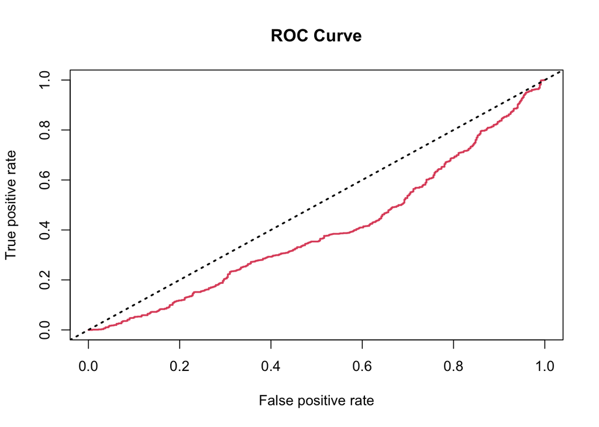

```r
library(caret)
library(dplyr)

# function to print confusion matrices for diffrent cut-off levels of probability
CmFn <- function(cutoff) {

       # predicting the test set results
         predictions_logistic <- predict(logistic_regression_model, dataTest, type = "response")
         C1 <- ifelse(predictions_logistic > cutoff, "1", "0")
         C2 <- dataTest$Feedback_Type
         predY   <- as.factor(C1)
         actualY <- as.factor(C2)

      predY <- ordered(predY, levels = c("1", "0"))
      actualY <- ordered(actualY, levels = c("1", "0"))

        # use the confusionMatrix from the caret package
        cm1 <-confusionMatrix(table(predY,actualY))
        # extracting accuracy
        Accuracy <- cm1$overall[1]
        # extracting sensitivity
          Sensitivity <- cm1$byClass[1]
        # extracting specificity
          Specificity <- cm1$byClass[2]
      # extracting value of kappa
          Kappa <- cm1$overall[2]

        # combined table
          tab <- cbind(Accuracy,Sensitivity,Specificity,Kappa)
        return(tab)}
     # making sequence of cut-off probabilities
        cutoff1 <- seq( .1, .9, by = .05 )
     # loop using "lapply"
        tab2    <- lapply(cutoff1, CmFn)
     # extra coding for saving table as desired format
        tab3 <- rbind(tab2[[1]],tab2[[2]],tab2[[3]],tab2[[4]],tab2[[5]],tab2[[6]],tab2[[7]],
                 tab2[[8]],tab2[[9]],tab2[[10]],tab2[[11]],tab2[[12]],tab2[[13]],tab2[[14]],
                 tab2[[15]],tab2[[16]],tab2[[17]])
        # printing the table
        tab4 <- as.data.frame(tab3)
        tab5 <- cbind(cutoff1,tab4$Accuracy,tab4$Sensitivity,tab4$Specificity,tab4$Kappa)
        tab6 <- as.data.frame(tab5)
        tab7 <- rename(tab6,cutoff =  cutoff1, Accuracy = V2 ,
                       Senstivity = V3 ,Specificity =  V4 ,kappa = V5)

#Plot a ROC Curve:
# loading the package
library(ROCR)

PredLR <- predict(logistic_regression_model, dataTest,type = "response")
lgPredObj <- prediction((1-PredLR),dataTest$Feedback_Type)
lgPerfObj <- performance(lgPredObj, "tpr","fpr")
# plotting ROC curve
plot(lgPerfObj,main = "ROC Curve",col = 2,lwd = 2)
abline(a = 0,b = 1,lwd = 2,lty = 3,col = "black")
```

```r
#AUC (Area Under the Curve)
library(ROCR)
# area under curve: 0.3973437
aucLR <- performance(lgPredObj, measure = "auc")
aucLR <- aucLR@y.values[[1]]
aucLR
```

```
## [1] 0.3973437
```

SECOND MODEL: Random Forest Modeling

https://www.youtube.com/watch?v=dJclNIN-TPo

random forest developed by aggregating trees. used for classification or regression. avoids overfitting. helps with feature selection based on importance. For classification: mtry default is sq.root(p) where p is the number of variables in the model.